# Presenting Regression Analyses in R: Part 2 Effect sizes and diagnostics

Kevin Donovan

April 16, 2021

# Introduction

- We have discussed how to do regression analyses
  - Presenting analyses to communicate results just as important
  - Maximizes the impact of your work
- Introduced ways to communicate results, continue this discussion
  - Focus on **metrics to use to quantify results** from analyses

[figure not shown]

Tidyverse

# Correlation analyses

- Recall our previous visualizations

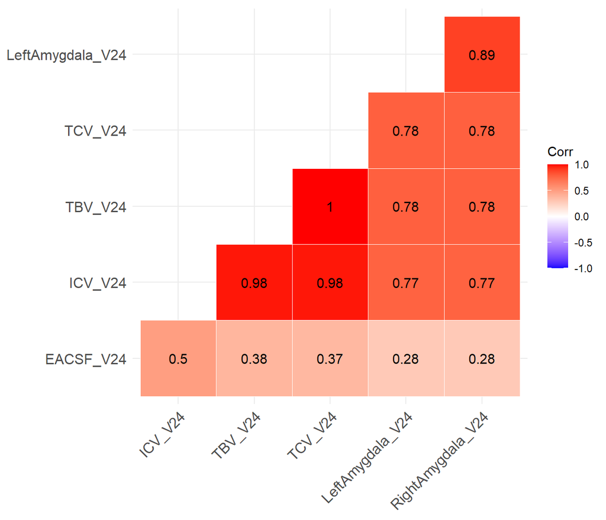

# Correlation analyses

- Correlations are an example of an **effect size metric**
  - Metric has **standardized units** of measure of the relationship
  - Strength is same **regardless of scale** for $X$, $Y$

$$\text{Cor}(X,Y)=\frac{\text{Cov}(X,Y)}{\text{Var}(X)\text{Var}(Y)}$$

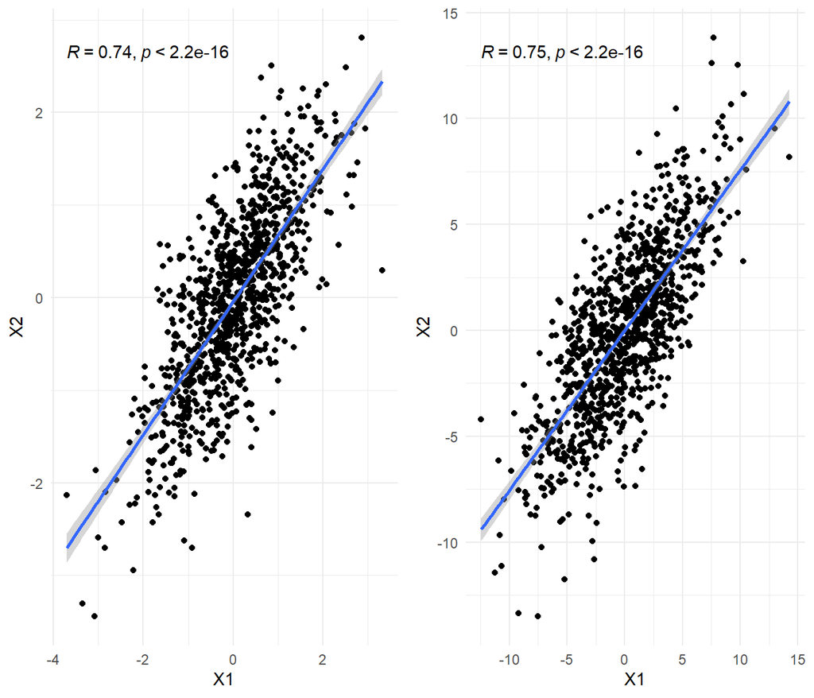

# Group differences

- Can use T-test and F-test to evaluate pairwise differences or multi-group differences:
  - $H_0: \mu_1=\mu_2$
  - $H_1: \mu_1\neq\mu_2$

$$T=\frac{\bar{X_1}-\bar{X_2}}{s_p\sqrt{\frac{1}{n_1}+\frac{1}{n_2}}} \sim \text{T}_{(n_1+n_2-2)}$$

- $H_0: \mu_1=\mu_2=\ldots=\mu_K$
- $H_1: \text{At least one = is } \neq$

$$F=\frac{\text{between-group variance}}{\text{within-group variance}} \sim \text{F}_{(K-1, N-K)}$$

# Group differences

- $\bar{X_1}-\bar{X_2}$ depends on units of variables
  - How big of a difference is ``big’’?
  - **Effect size**: *Cohen’s D*

$$d=\frac{\bar{X_1}-\bar{X_2}}{s_p}$$

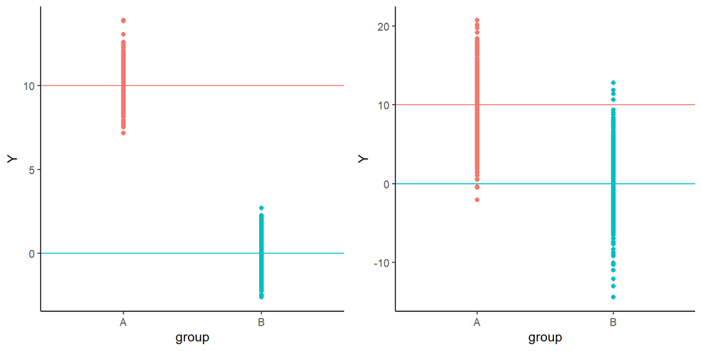

- I.e., just standardizing difference by spread

# Group differences

- How about for F-Test?
  - **Cohen’s $f^2$**:

$$\begin{align}
&f^2=\frac{\eta^2}{1-\eta^2} \\
&\text{ where } \eta^2=\frac{SS_{group}}{SS_{total}}=\frac{SS_{group}}{SS_{group}+SS_{error}}
\end{align}$$

- I.e., how much of the variability in variable is related to groups?
- Easy to calculate from `lm` function in R

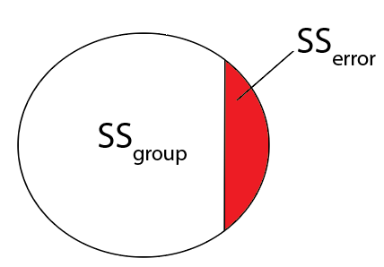

# Summary statistics

- Can create easily formatted summary stats tables **in code**
- Add in effect sizes using `add_stat`

| Characteristic | N | HR-ASD, N = 781 | HR-Neg, N = 2731 | p-value2 | ES (95% CI)3 |
| --- | --- | --- | --- | --- | --- |
| EACSF_V24 | 219 | 72,487 (16,123) | 70,358 (15,022) | 0.4 | 0.14 (-0.18, 0.46) |
| Missing |  | 30 | 102 |  |  |
| ICV_V24 | 262 | 1,270,041 (123,302) | 1,223,180 (108,795) | 0.006 | 0.42 (0.12, 0.72) |
| Missing |  | 23 | 66 |  |  |
| TBV_V24 | 262 | 1,104,088 (107,222) | 1,064,502 (95,094) | 0.008 | 0.4 (0.1, 0.7) |
| Missing |  | 23 | 66 |  |  |
| TCV_V24 | 262 | 973,873 (99,189) | 938,532 (86,327) | 0.009 | 0.4 (0.1, 0.7) |
| Missing |  | 23 | 66 |  |  |
| LeftAmygdala_V24 | 262 | 1,071 (132) | 1,029 (103) | 0.013 | 0.38 (0.08, 0.68) |
| Missing |  | 23 | 66 |  |  |
| RightAmygdala_V24 | 262 | 1,072 (115) | 1,036 (97) | 0.020 | 0.35 (0.06, 0.65) |
| Missing |  | 23 | 66 |  |  |

1Mean (SD)  
2One-way ANOVA  
3Cohen's D (95% CI)

# Summary statistics in regression

- ANOVA
  - Recall: **ANOVA = F-test for multi-group differences**
  - Model:

$$\begin{align}
&MSEL = \beta_0+\beta_1*I(Group=\text{HR-ASD})+\beta_2*I(Group=\text{HR-Neg})+\epsilon \\
& I(Group=\text{x}) \text{ is dummy variable for group x} \\
& \rightarrow \text{LR is reference group}
\end{align}$$

- Now can express group difference test in terms of $\beta$

$$\begin{align}
&H_0: \mu_{LR}=\mu_{HR-ASD}=\mu_{HR-Neg} \leftrightarrow\\
&H_0: \beta_0=\beta_0+\beta_1=\beta_0+\beta_2 \leftrightarrow\\
&H_0: \beta_1=\beta_2=0
\end{align}$$

- $\rightarrow$ can use Cohen’s $f^2$ for effect size

# Summary statistics in regression

- General regression
  - Consider model

$$MSEL = \beta_0+\beta_1*I(Group=\text{HR-ASD})+\beta_2*I(Group=\text{HR-Neg})+\beta_3*TCV +\epsilon$$

$$\begin{align}
&SS_{total}=\sum_{i=1}^{n}(y_i-\bar{y})^2 \\
&SS_{error}=\sum_{i=1}^{n}(\epsilon_i)^2
\end{align}$$

# Summary statistics in regression

- Mixed models
  - Consider model

$$MSEL = \beta_0+\beta_1*I(Group=\text{HR-ASD})+\beta_2*I(Group=\text{HR-Neg})+\beta_3*TCV+\beta_4*Age+\delta_{0,i}+\delta_{1,i}*Age +\epsilon$$

# Regression diagnostics

- With modeling need to assess model fit
  - Residual distribution and variance
  - Outliers and their effects on results
- Can easily create visuals using `ggfortify` and `olsrr`

# Regression diagnostics

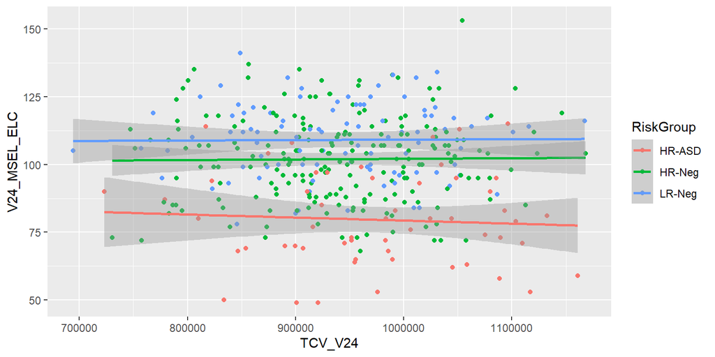

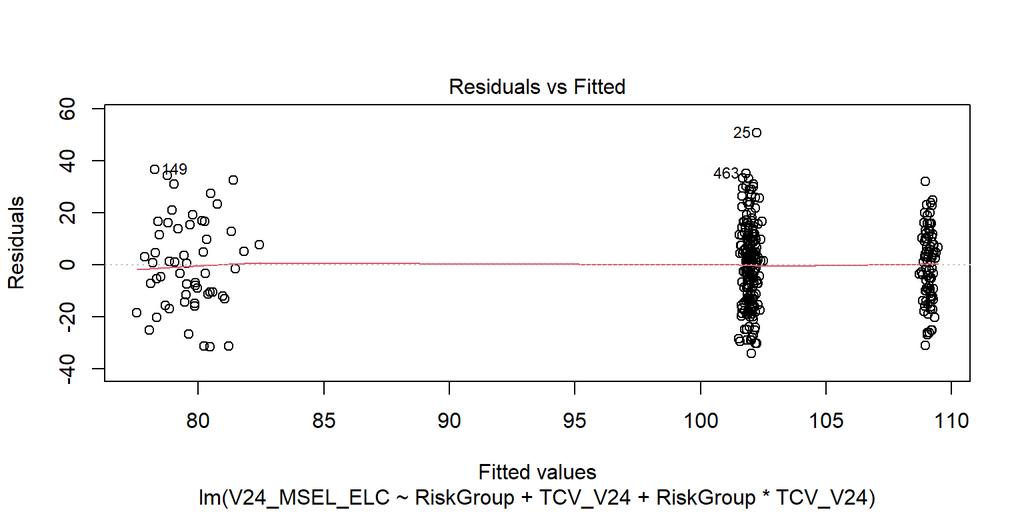

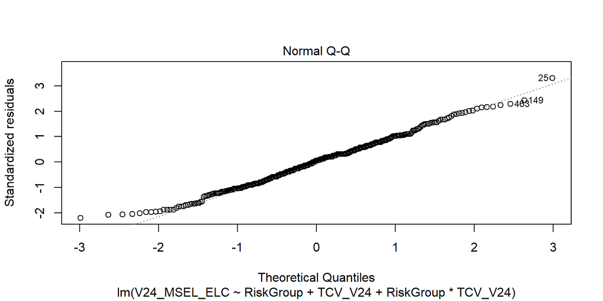

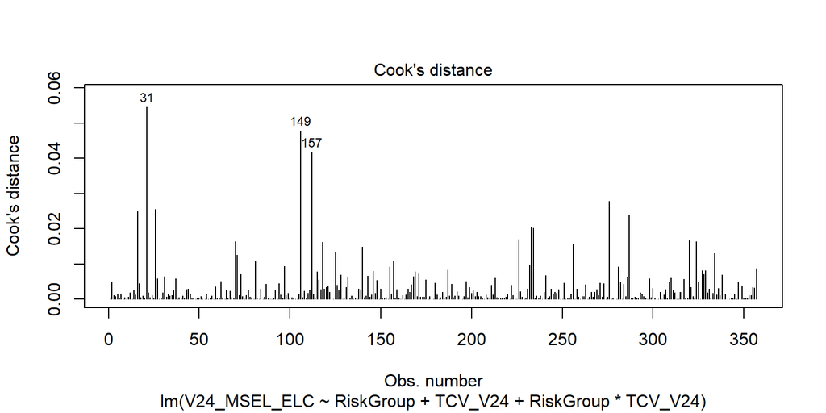

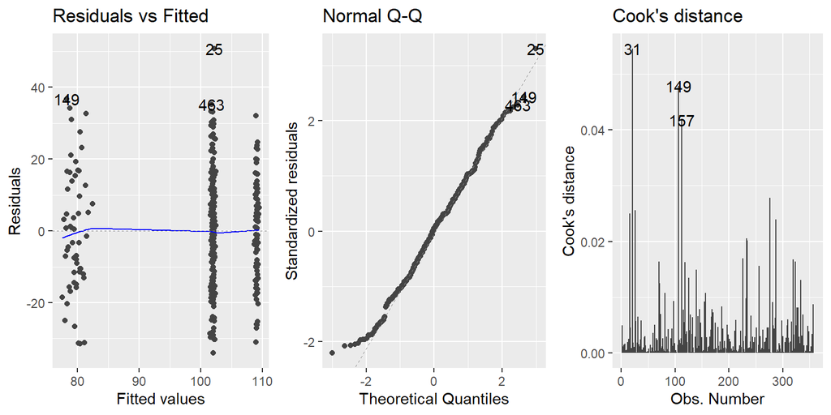

# Customized visualizations

- Can use `flextable` package with results stored as **data frame**
  - Create any table you want
- Can use `ggplot` with `ggpubr` to combine figures

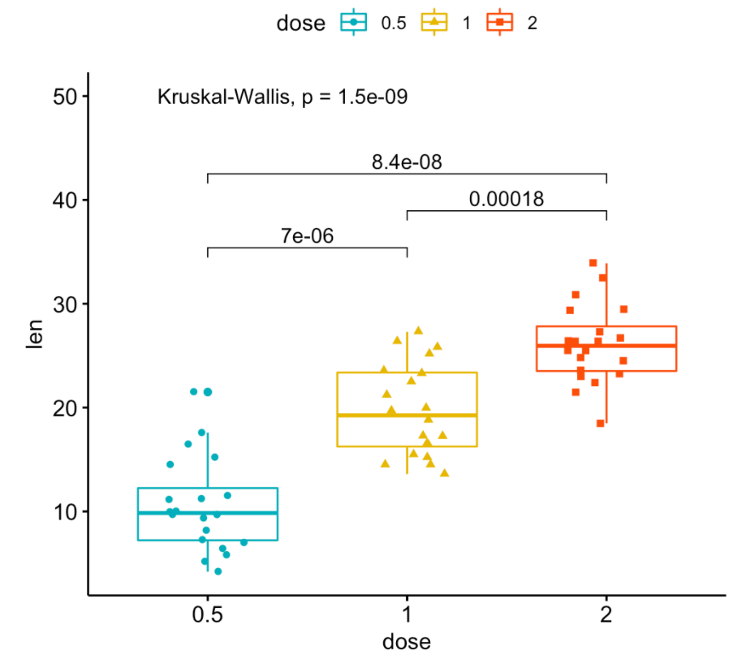

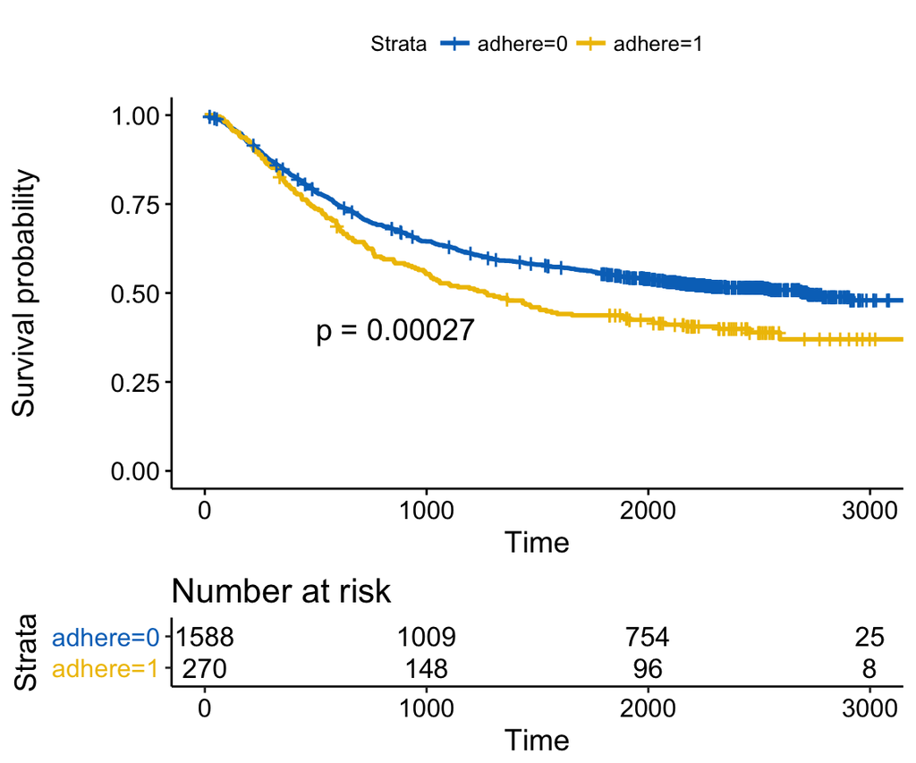